# Bike Sharing data exploration Part 1

## Introduction

> This data set includes information about individual rides made in a bike-sharing system covering the greater San Francisco Bay area.

## Preliminary Wrangling

```python
# import all packages and set plots to be embedded inline
import warnings
warnings.filterwarnings('ignore')

import numpy as np
import pandas as pd
import matplotlib.pyplot as plt
import seaborn as sb

%matplotlib inline
```

```python
# Load dataset
bikeData = pd.read_csv('201902-fordgobike-tripdata.csv')
```

```python
bikeData.head()
```

|  | duration_sec | start_time | end_time | start_station_id | start_station_name | start_station_latitude | start_station_longitude | end_station_id | end_station_name | end_station_latitude | end_station_longitude | bike_id | user_type | member_birth_year | member_gender | bike_share_for_all_trip |
| --- | --- | --- | --- | --- | --- | --- | --- | --- | --- | --- | --- | --- | --- | --- | --- | --- |
| 0 | 52185 | 2019-02-28 17:32:10.1450 | 2019-03-01 08:01:55.9750 | 21.0 | Montgomery St BART Station (Market St at 2nd St) | 37.789625 | -122.400811 | 13.0 | Commercial St at Montgomery St | 37.794231 | -122.402923 | 4902 | Customer | 1984.0 | Male | No |
| 1 | 42521 | 2019-02-28 18:53:21.7890 | 2019-03-01 06:42:03.0560 | 23.0 | The Embarcadero at Steuart St | 37.791464 | -122.391034 | 81.0 | Berry St at 4th St | 37.775880 | -122.393170 | 2535 | Customer | NaN | NaN | No |
| 2 | 61854 | 2019-02-28 12:13:13.2180 | 2019-03-01 05:24:08.1460 | 86.0 | Market St at Dolores St | 37.769305 | -122.426826 | 3.0 | Powell St BART Station (Market St at 4th St) | 37.786375 | -122.404904 | 5905 | Customer | 1972.0 | Male | No |
| 3 | 36490 | 2019-02-28 17:54:26.0100 | 2019-03-01 04:02:36.8420 | 375.0 | Grove St at Masonic Ave | 37.774836 | -122.446546 | 70.0 | Central Ave at Fell St | 37.773311 | -122.444293 | 6638 | Subscriber | 1989.0 | Other | No |
| 4 | 1585 | 2019-02-28 23:54:18.5490 | 2019-03-01 00:20:44.0740 | 7.0 | Frank H Ogawa Plaza | 37.804562 | -122.271738 | 222.0 | 10th Ave at E 15th St | 37.792714 | -122.248780 | 4898 | Subscriber | 1974.0 | Male | Yes |

```python
bikeData.info()
```

```
<class 'pandas.core.frame.DataFrame'>
RangeIndex: 183412 entries, 0 to 183411
Data columns (total 16 columns):
 #   Column                   Non-Null Count   Dtype
---  ------                   --------------   -----
 0   duration_sec             183412 non-null  int64
 1   start_time               183412 non-null  object
 2   end_time                 183412 non-null  object
 3   start_station_id         183215 non-null  float64
 4   start_station_name       183215 non-null  object
 5   start_station_latitude   183412 non-null  float64
 6   start_station_longitude  183412 non-null  float64
 7   end_station_id           183215 non-null  float64
 8   end_station_name         183215 non-null  object
 9   end_station_latitude     183412 non-null  float64
 10  end_station_longitude    183412 non-null  float64
 11  bike_id                  183412 non-null  int64
 12  user_type                183412 non-null  object
 13  member_birth_year        175147 non-null  float64
 14  member_gender            175147 non-null  object
 15  bike_share_for_all_trip  183412 non-null  object
dtypes: float64(7), int64(2), object(7)
memory usage: 22.4+ MB
```

```python
bikeData.describe()
```

|  | duration_sec | start_station_id | start_station_latitude | start_station_longitude | end_station_id | end_station_latitude | end_station_longitude | bike_id | member_birth_year |
| --- | --- | --- | --- | --- | --- | --- | --- | --- | --- |
| count | 183412.000000 | 183215.000000 | 183412.000000 | 183412.000000 | 183215.000000 | 183412.000000 | 183412.000000 | 183412.000000 | 175147.000000 |
| mean | 726.078435 | 138.590427 | 37.771223 | -122.352664 | 136.249123 | 37.771427 | -122.352250 | 4472.906375 | 1984.806437 |
| std | 1794.389780 | 111.778864 | 0.099581 | 0.117097 | 111.515131 | 0.099490 | 0.116673 | 1664.383394 | 10.116689 |
| min | 61.000000 | 3.000000 | 37.317298 | -122.453704 | 3.000000 | 37.317298 | -122.453704 | 11.000000 | 1878.000000 |
| 25% | 325.000000 | 47.000000 | 37.770083 | -122.412408 | 44.000000 | 37.770407 | -122.411726 | 3777.000000 | 1980.000000 |
| 50% | 514.000000 | 104.000000 | 37.780760 | -122.398285 | 100.000000 | 37.781010 | -122.398279 | 4958.000000 | 1987.000000 |
| 75% | 796.000000 | 239.000000 | 37.797280 | -122.286533 | 235.000000 | 37.797320 | -122.288045 | 5502.000000 | 1992.000000 |
| max | 85444.000000 | 398.000000 | 37.880222 | -121.874119 | 398.000000 | 37.880222 | -121.874119 | 6645.000000 | 2001.000000 |

```python
bikeData.isna().sum().sum()
```

```
17318
```

```python
na_counts = bikeData.isna().sum()
```

#### What is the distribution of NaN in the columns?

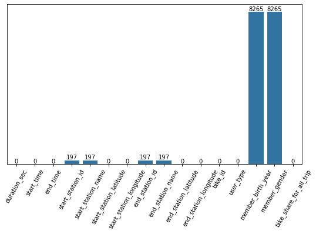

```python
plt.figure(figsize=(9, 5))
base_color = sb.color_palette()[0]
sb.barplot(na_counts.index.values, na_counts, color=base_color);
plt.xticks(rotation=60);
plt.yticks([])

for i in range(na_counts.shape[0]):
    count = na_counts[i]
    plt.text(i, count+300, count, ha='center', va='top')
```

> From the distribution above, we see that member birth year and member gender have the highest number of NaN, 8265.

### Assessing Data

- Some rows have missing data (NaN)
- Some columns should be converted to datetime format
- Drop columns that are not needed
- Convert categorical columns

### Clean Data

##### 1. Define: Drop rows with NaN

##### Code

```python
bikeData.dropna(inplace=True)
```

##### Test

```python
bikeData.isna().sum().sum()
```

```
0
```

##### 2. Define: Convert columns to datetime

##### Code

```python
bikeData['start_time'] = bikeData['start_time'].astype('datetime64[ns]')
bikeData['end_time'] = bikeData['end_time'].astype('datetime64[ns]')
bikeData['member_birth_year'] = bikeData['member_birth_year'].astype('int')
```

##### Test

```python
bikeData.info()
```

```
<class 'pandas.core.frame.DataFrame'>
Int64Index: 174952 entries, 0 to 183411
Data columns (total 16 columns):
 #   Column                   Non-Null Count   Dtype
---  ------                   --------------   -----
 0   duration_sec             174952 non-null  int64
 1   start_time               174952 non-null  datetime64[ns]
 2   end_time                 174952 non-null  datetime64[ns]
 3   start_station_id         174952 non-null  float64
 4   start_station_name       174952 non-null  object
 5   start_station_latitude   174952 non-null  float64
 6   start_station_longitude  174952 non-null  float64
 7   end_station_id           174952 non-null  float64
 8   end_station_name         174952 non-null  object
 9   end_station_latitude     174952 non-null  float64
 10  end_station_longitude    174952 non-null  float64
 11  bike_id                  174952 non-null  int64
 12  user_type                174952 non-null  object
 13  member_birth_year        174952 non-null  int32
 14  member_gender            174952 non-null  object
 15  bike_share_for_all_trip  174952 non-null  object
dtypes: datetime64[ns](2), float64(6), int32(1), int64(2), object(5)
memory usage: 22.0+ MB
```

##### 3. Define: Drop columns that are not needed

##### Code

```python
bikeData.drop(['start_station_id', 'end_station_id'], axis=1, inplace=True)
```

##### Test

```python
bikeData.info()
```

```
<class 'pandas.core.frame.DataFrame'>
Int64Index: 174952 entries, 0 to 183411
Data columns (total 14 columns):
 #   Column                   Non-Null Count   Dtype
---  ------                   --------------   -----
 0   duration_sec             174952 non-null  int64
 1   start_time               174952 non-null  datetime64[ns]
 2   end_time                 174952 non-null  datetime64[ns]
 3   start_station_name       174952 non-null  object
 4   start_station_latitude   174952 non-null  float64
 5   start_station_longitude  174952 non-null  float64
 6   end_station_name         174952 non-null  object
 7   end_station_latitude     174952 non-null  float64
 8   end_station_longitude    174952 non-null  float64
 9   bike_id                  174952 non-null  int64
 10  user_type                174952 non-null  object
 11  member_birth_year        174952 non-null  int32
 12  member_gender            174952 non-null  object
 13  bike_share_for_all_trip  174952 non-null  object
dtypes: datetime64[ns](2), float64(4), int32(1), int64(2), object(5)
memory usage: 19.4+ MB
```

##### 4. Define: Convert categorical columns

- user_type, member_gender, bike_share_for_all_trip, member_birth_year

##### Code

```python
# convert cut, color, and clarity into ordered categorical types
nominal_var_dict = {'member_gender': ['Male', 'Female', 'Other'],
                    'user_type': ['Subscriber', 'Customer'],
                    'bike_share_for_all_trip': ['Yes', 'No']}

for var in nominal_var_dict:
    unordered_var = pd.api.types.CategoricalDtype(ordered = False, categories = nominal_var_dict[var])
    bikeData[var] = bikeData[var].astype(unordered_var)
# bikeData['member_birth_year'] = bikeData['member_birth_year'].astype
```

##### Test

```python
bikeData.info()
```

```
<class 'pandas.core.frame.DataFrame'>
Int64Index: 174952 entries, 0 to 183411
Data columns (total 14 columns):
 #   Column                   Non-Null Count   Dtype
---  ------                   --------------   -----
 0   duration_sec             174952 non-null  int64
 1   start_time               174952 non-null  datetime64[ns]
 2   end_time                 174952 non-null  datetime64[ns]
 3   start_station_name       174952 non-null  object
 4   start_station_latitude   174952 non-null  float64
 5   start_station_longitude  174952 non-null  float64
 6   end_station_name         174952 non-null  object
 7   end_station_latitude     174952 non-null  float64
 8   end_station_longitude    174952 non-null  float64
 9   bike_id                  174952 non-null  int64
 10  user_type                174952 non-null  category
 11  member_birth_year        174952 non-null  int32
 12  member_gender            174952 non-null  category
 13  bike_share_for_all_trip  174952 non-null  category
dtypes: category(3), datetime64[ns](2), float64(4), int32(1), int64(2), object(2)
memory usage: 15.9+ MB
```

### What is the structure of your dataset?

The dataset has records 183,412 rides and has 16 features. There are 7 columns that are floats, 2 of them are ints, while 7 are object (strings).

user_type: Subscriber, Customer \ member_gender: Male, Female, Other \ bike_share_for_all_trip: Yes, No

### What is/are the main feature(s) of interest in your dataset?

I am interested in understanding which features affect the duration and ride distance (to be engineered) of the ride.

### What features in the dataset do you think will help support your investigation into your feature(s) of interest?

I expect that start_longitude and start_latitude, member_gender, user_type, and member_birth_year will have effect on each bike ride's duration:

## Utility functions

```python
def createCountPlot(df, variable, color=sb.color_palette()[0], hue = None, palette = None):
    """
    Given a particular dataframe and variable, this function plots a count plot of the values therein

    Parameters:
        df (Dataframe): The dataset
        variable (string): name of the column
    """
    # Set dimensions
    plt.figure(figsize=[14, 8])

    # Plot countplot
    sb.countplot(data=df, x=variable, edgecolor='black', color=color);

    variableText = variable.split('_')
    variableText = " ".join(variableText).title()

    # Add title with formatting
    plt.title(f'Distribution of {variableText}'.title(), fontsize=13, weight='bold')

    # Add x label with formatting
    plt.xlabel(variableText.title(), fontsize=10, weight='bold')

    # Add y label with formatting
    plt.ylabel('Frequency', fontsize=10, weight='bold')
```

```python
import math
def calculateHaversine(currentRow):
    """This function returns the haversine given the latitudes and longitudes for the start and end.
    The Haversine Formula computes the great-circle distance, the shortest distance between two
    points on the surface of a Sphere).

    Parameters:
        currentRow (Series): The row that you want to calculate the havesine for
    Return:
        haversine (float): The haversine calculated from the start/end longitudes and latitudes in metres
    """
    start_station_longitude = math.radians(currentRow['start_station_longitude'])
    end_station_longitude = math.radians(currentRow['end_station_longitude'])
    start_station_latitude = math.radians(currentRow['start_station_latitude'])
    end_station_latitude = math.radians(currentRow['end_station_latitude'])

    # Haversine formula
    diffOfLongitude = end_station_longitude - start_station_longitude
    diffOfLatitude = end_station_latitude - start_station_latitude

    a = math.sin(diffOfLatitude / 2)**2 + math.cos(start_station_latitude) * math.cos(end_station_latitude) * math.sin(diffOfLongitude / 2)**2
    c = 2 * math.asin(math.sqrt(a))

    # Radius of earth in kilometers. Use 3956 for miles
    r = 6371

    # calculate the result
    return(c * r * 1000)
```

## Feature Engineering

### Create ride distance columns

> Create a new column, ride_distance (in metres) from the start/end longitude and latitudes

```python
bikeData['ride_distance'] = bikeData.apply(lambda x: calculateHaversine(x), axis=1)
```

```python
bikeData.head()
```

|  | duration_sec | start_time | end_time | start_station_name | start_station_latitude | start_station_longitude | end_station_name | end_station_latitude | end_station_longitude | bike_id | user_type | member_birth_year | member_gender | bike_share_for_all_trip | ride_distance |
| --- | --- | --- | --- | --- | --- | --- | --- | --- | --- | --- | --- | --- | --- | --- | --- |
| 0 | 52185 | 2019-02-28 17:32:10.145 | 2019-03-01 08:01:55.975 | Montgomery St BART Station (Market St at 2nd St) | 37.789625 | -122.400811 | Commercial St at Montgomery St | 37.794231 | -122.402923 | 4902 | Customer | 1984 | Male | No | 544.708503 |
| 2 | 61854 | 2019-02-28 12:13:13.218 | 2019-03-01 05:24:08.146 | Market St at Dolores St | 37.769305 | -122.426826 | Powell St BART Station (Market St at 4th St) | 37.786375 | -122.404904 | 5905 | Customer | 1972 | Male | No | 2704.545131 |
| 3 | 36490 | 2019-02-28 17:54:26.010 | 2019-03-01 04:02:36.842 | Grove St at Masonic Ave | 37.774836 | -122.446546 | Central Ave at Fell St | 37.773311 | -122.444293 | 6638 | Subscriber | 1989 | Other | No | 260.738544 |
| 4 | 1585 | 2019-02-28 23:54:18.549 | 2019-03-01 00:20:44.074 | Frank H Ogawa Plaza | 37.804562 | -122.271738 | 10th Ave at E 15th St | 37.792714 | -122.248780 | 4898 | Subscriber | 1974 | Male | Yes | 2409.301416 |
| 5 | 1793 | 2019-02-28 23:49:58.632 | 2019-03-01 00:19:51.760 | 4th St at Mission Bay Blvd S | 37.770407 | -122.391198 | Broadway at Kearny | 37.798014 | -122.405950 | 5200 | Subscriber | 1959 | Male | No | 3332.202628 |

## Univariate Exploration

> I'll start by looking at the distribution of the whole dataset

#### What is the distribution of all the numeric variables in the dataset?

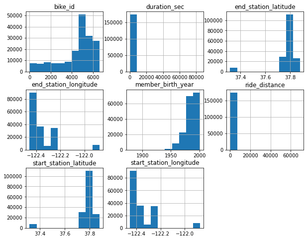

```python
bikeData.hist(figsize=(10,8));
```

> This is a distribution of all the numeric variables in the dataset. We can see that some of the variables have instances with outliers and some have large portions with almost no data.

#### What is the distribution of `duration_sec`?

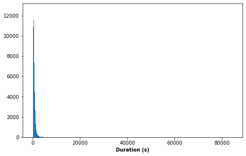

```python
# start with a standard-scaled plot
binsize = 50
bins = np.arange(0, bikeData['duration_sec'].max()+binsize, binsize)

plt.figure(figsize=[8, 5])
plt.hist(data = bikeData, x = 'duration_sec', bins = bins)
plt.xlabel('Duration (s)', fontsize=10, weight='bold')
#plt.xlim(0, 3000)
plt.show()
```

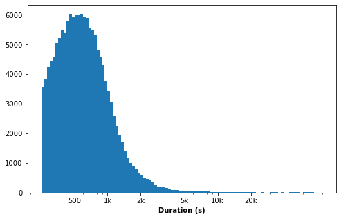

```python
# Let's put the previous illustration on a log scale instead
log_binsize = 0.025
bins = 10 ** np.arange(2.4, np.log10(bikeData['duration_sec'].max())+log_binsize, log_binsize)

plt.figure(figsize=[8, 5])
plt.hist(data = bikeData, x = 'duration_sec', bins = bins)
plt.xscale('log')
plt.xticks([500, 1e3, 2e3, 5e3, 1e4, 2e4], [500, '1k', '2k', '5k', '10k', '20k'])
plt.xlabel('Duration (s)', fontsize=10, weight='bold')
plt.show()
```

From the distributions above, we can see that most of the rides have a duration of between 200 seconds (about 3.33 minutes) and 2000 seconds (33.3 minutes). We can see that there are lots of outliers. We would remove those from the dataset.

Let us look at the distribution of the ride_distance variable

```python
# Based on the distribution of duration_sec, we select the
# outliers that have a duration of less than 3000 seconds
bikeDataFiltered = bikeData.query('duration_sec <= 3000')
```

#### What is the distribution of the ride distance?

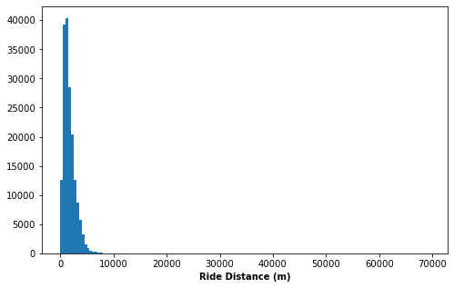

```python
binsize = 500
bins = np.arange(0, bikeData['ride_distance'].max()+binsize, binsize)

plt.figure(figsize=[8, 5])
plt.hist(data = bikeData, x = 'ride_distance', bins = bins)
plt.xlabel('Ride Distance (m)', fontsize=10, weight='bold')
plt.show()
```

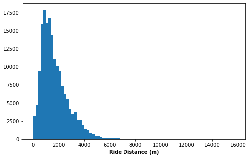

```python
# Same plot with bikeDataFiltered dataset
binsize = 200
bins = np.arange(0, bikeDataFiltered['ride_distance'].max()+binsize, binsize)

plt.figure(figsize=[8, 5])
plt.hist(data = bikeDataFiltered, x = 'ride_distance', bins=bins)
plt.xlabel('Ride Distance (m)', fontsize=10, weight='bold')
plt.show()
```

> Distribution of ride distance using the filtered data

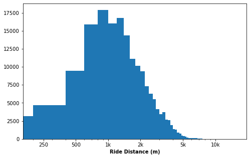

```python
binsize = 200
bins = np.arange(0, bikeDataFiltered['ride_distance'].max()+binsize, binsize)

plt.figure(figsize=[8, 5])
plt.hist(data = bikeDataFiltered, x = 'ride_distance', bins=bins)
plt.xlabel('Ride Distance (m)', fontsize=10, weight='bold')
plt.xscale('log')
plt.xticks([250, 500, 1e3, 2e3, 5e3, 1e4], [250, 500, '1k', '2k', '5k', '10k'])
plt.show()
```

> From the distribution of the ride distance, we see that most of the ride distance are between 0 and 2000 metres. The distribution is highly right-skewed and unimodal in nature. I use a logarithms scale to make better sense of the data?

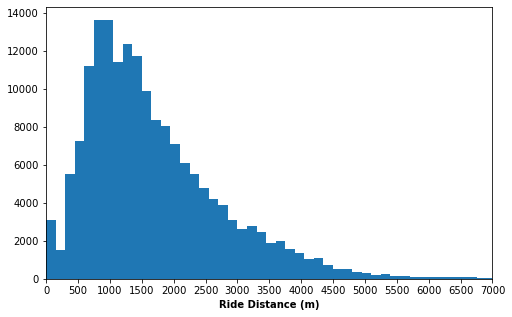

```python
bins = np.arange(0, 8000, 150)

plt.figure(figsize=[8, 5])
plt.hist(data = bikeDataFiltered, x = 'ride_distance', bins=bins)
plt.xlabel('Ride Distance (m)', fontsize=10, weight='bold')
plt.xlim(0, 7000)
tick_values = np.arange(0, 7500, 500)
tick_names = ['{:0.0f}'.format(v) for v in tick_values]
plt.xticks(tick_values, tick_names)
plt.show()
```

From the distributions above, we can see that most of the rides have a distance between 500 and 2500 metres. It is observed that the distribution is unimodal and right-skewed. We also observe that there are some outliers in the ride distance; some extreme values above 60000 metres. Consequently, we would drop those rows that have those outliers.

#### What is the distribution of member gender?

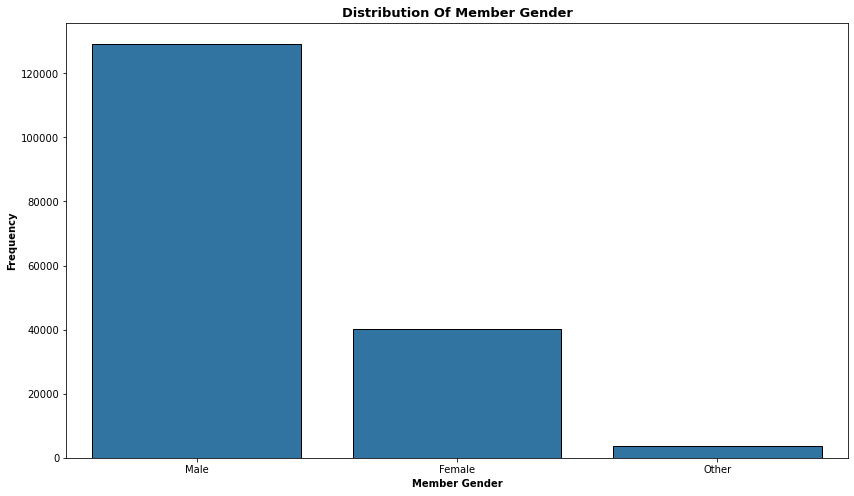

```python
base_color = sb.color_palette()[0]
createCountPlot(bikeDataFiltered, 'member_gender')
```

> We can see that the most of the members who take rides are males (over 120,000). There are about 40,000 females, while very few people selected *Other*.

#### What is the distribution of user type?

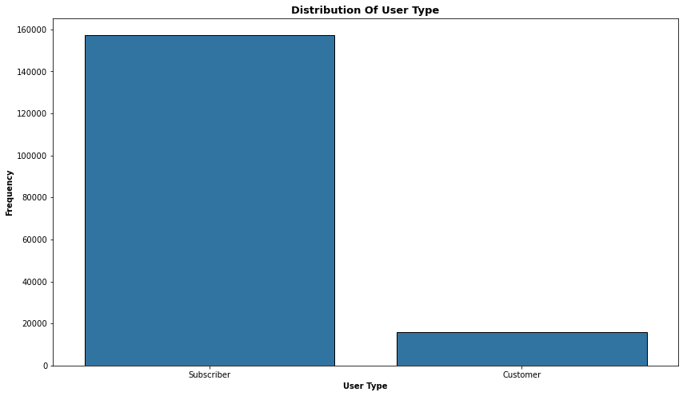

```python
createCountPlot(bikeDataFiltered, 'user_type')
```

#### What is the distribution of bike share for all trip?

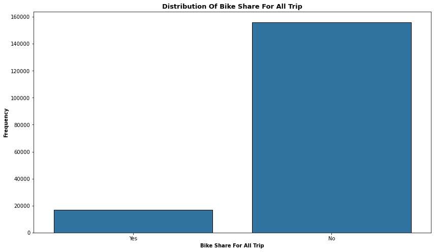

```python
createCountPlot(bikeDataFiltered, 'bike_share_for_all_trip')
```

#### What is the distribution of member birth year?

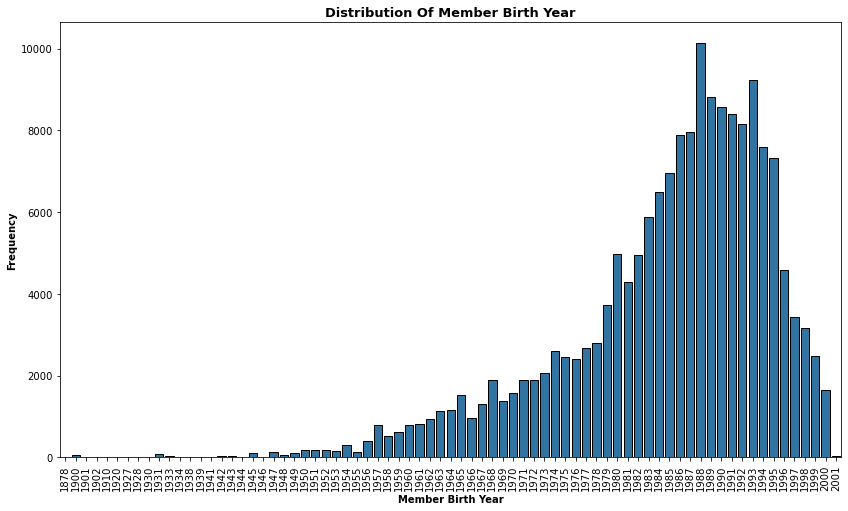

```python
createCountPlot(bikeDataFiltered, 'member_birth_year')
plt.xticks(rotation=90);
```

> The distribution shows that most of the members were born between 1970 and 1996

```python
bikeDataFiltered = bikeDataFiltered.query('ride_distance <= 7000')
```

```python
bikeDataFiltered.describe()
```

|  | duration_sec | start_station_latitude | start_station_longitude | end_station_latitude | end_station_longitude | bike_id | member_birth_year | ride_distance |
| --- | --- | --- | --- | --- | --- | --- | --- | --- |
| count | 172859.000000 | 172859.000000 | 172859.000000 | 172859.000000 | 172859.000000 | 172859.000000 | 172859.000000 | 172859.000000 |
| mean | 608.893543 | 37.771101 | -122.351614 | 37.771298 | -122.351168 | 4480.435968 | 1984.811818 | 1685.040151 |
| std | 416.591786 | 0.100586 | 0.117887 | 0.100490 | 0.117437 | 1660.428253 | 10.109289 | 1060.189824 |
| min | 61.000000 | 37.317298 | -122.453704 | 37.317298 | -122.453704 | 11.000000 | 1878.000000 | 0.000000 |
| 25% | 321.000000 | 37.770407 | -122.411901 | 37.770407 | -122.411647 | 3796.000000 | 1980.000000 | 913.223965 |
| 50% | 505.000000 | 37.780760 | -122.398279 | 37.781010 | -122.397405 | 4959.000000 | 1987.000000 | 1429.829338 |
| 75% | 775.000000 | 37.797320 | -122.283093 | 37.797673 | -122.285633 | 5505.000000 | 1992.000000 | 2218.047872 |
| max | 2997.000000 | 37.880222 | -121.874119 | 37.880222 | -121.874119 | 6645.000000 | 2001.000000 | 6985.492616 |

### Discuss the distribution(s) of your variable(s) of interest. Were there any unusual points? Did you need to perform any transformations?

> The duration and ride_distance variable took on a large range of values, so I looked at the both features using a log transform. The distribution of both variables are unimodal and right-skewed.

### Of the features you investigated, were there any unusual distributions? Did you perform any operations on the data to tidy, adjust, or change the form of the data? If so, why did you do this?

> When I investigated the feature I engineered, 'ride_distance', I noticed that there were lots of outliers. Consequently, I filtered them out of the dataset.

## Bivariate Exploration

#### What is the level of correlation between the numeric variables?

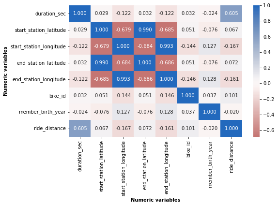

```python
# correlation plot
plt.figure(figsize = [8, 5])
sb.heatmap(bikeDataFiltered.corr(), annot = True, fmt = '.3f', cmap = 'vlag_r', center = 0)
plt.xlabel('Numeric variables', fontsize=10, weight='bold')
plt.ylabel('Numeric variables', fontsize=10, weight='bold')
plt.show()
```

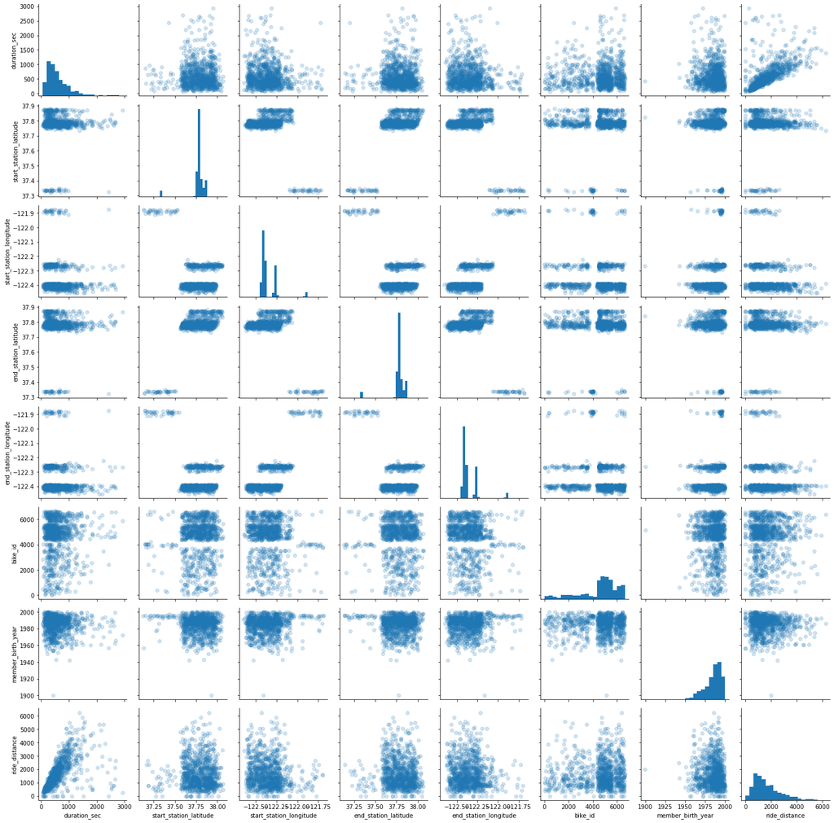

```python
# plot matrix: sample 1000 bike rides so that plots are clearer and they render faster
bike_rides_samp = bikeDataFiltered.sample(n=1000, replace = False)

#g = sb.PairGrid(data = bike_rides_samp, vars = numeric_vars)
g = sb.PairGrid(data = bike_rides_samp);
g = g.map_diag(plt.hist, bins = 20)
g.map_offdiag(sb.regplot, x_jitter=0.2, scatter_kws={'alpha':1/5}, fit_reg=False);
#sb.regplot(truncate=False, x_jitter=0.3, scatter_kws={'alpha':1/5}, fit_reg=False);
```

> From the chart above, we see that most of the numeric variables do not have correlation with one another. However, it is observed there is strong positive correlation between ride_distance and duration_sec (as expected).

#### What is the relationship between member birth year and duration_sec?

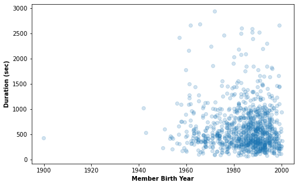

```python
plt.figure(figsize=[8, 5])
#plt.scatter(data = bike_rides_samp, x = 'member_birth_year', y = 'duration_sec')
sb.regplot(data = bike_rides_samp, x = 'member_birth_year', y = 'duration_sec',
           truncate=False, x_jitter=0.3, scatter_kws={'alpha':1/5}, fit_reg=False);
plt.xlabel('Member Birth Year', fontsize=10, weight='bold')
plt.ylabel('Duration (sec)', fontsize=10, weight='bold')
plt.show()
```

#### What is the relationship between member birth year and duration_sec?

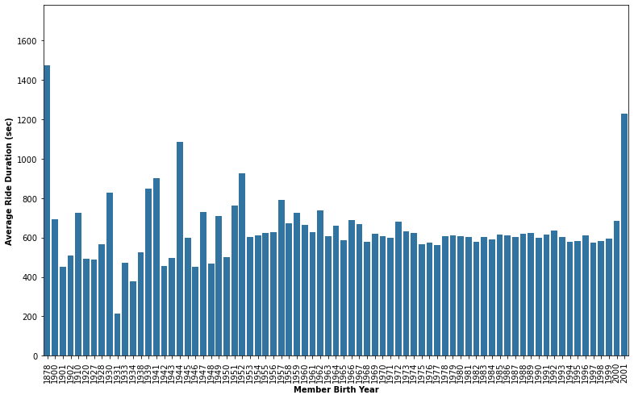

```python
plt.figure(figsize=[13, 8])
sb.barplot(data = bikeDataFiltered, x = 'member_birth_year', y = 'duration_sec', color=base_color, errwidth=0);
plt.xlabel('Member Birth Year', fontsize=10, weight='bold')
plt.ylabel('Average Ride Duration (sec)', fontsize=10, weight='bold')
plt.xticks(rotation=90)
plt.show()
```

> The scatter plot above shows that most of the members were born between 1980 and 2000. From the barplot above, we see that 1931 and 1934 have the lowest average ride duration while 1878 & 2001 has the highest average ride duration.

#### Select sample of 3000 bike rides

```python
# Sample of 3000 bike rides
bike_rides_samp = bikeDataFiltered.sample(n=3000, replace = False)
```

#### What is the relationship between ride_duration/duration_sec and user type, member gender, and bike share for all trip?

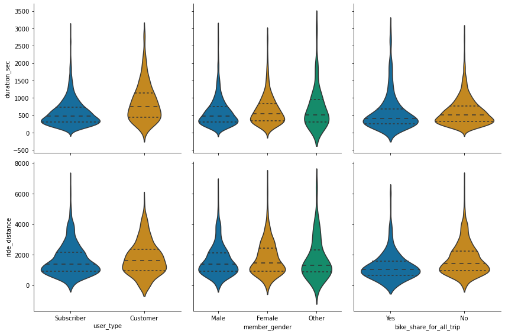

```python
# plot matrix of numeric features against categorical features.
categoric_vars = ['user_type', 'member_gender', 'bike_share_for_all_trip']
plt.figure(figsize = [10, 15]);
g = sb.PairGrid(data = bike_rides_samp, y_vars = ['duration_sec', 'ride_distance'],
                x_vars = categoric_vars, height = 3, size = 4, palette='colorblind');
g.map(sb.violinplot, inner='quartiles');
plt.show();
```

> From the visualization above, we can observe that the distributions for both the ride_distance and duration_sec are quite similar (as expected). We see that most Subscribers have a shorter ride distance and duration. We also see that males and females have similar distribution in terms of ride distance and duration. Other genders have a slightly higher average ride duration and distance. Lastly, we see that regardless of whether the rider is enrolled in the bike share for all trip program or not, their distributions are similar; although those that are not enrolled in the bike share for all trip program have a slightly higher average ride distance.

```python
# Select members born between 1960 and 2001
bikeDataFilteredYear = bikeDataFiltered[(bikeDataFiltered['member_birth_year'] >= 1960) & (bikeDataFiltered['member_birth_year'] <= 2001)]
```

```python
bikeDataFilteredYear.shape
```

```
(168760, 15)
```

```python
bikeDataFiltered.shape

print(bikeDataFiltered.shape[0] - bikeDataFilteredYear.shape[0])
```

```
4099
```

#### What is the relationship between member birth year and user type, member gender, and bike share for all trip?

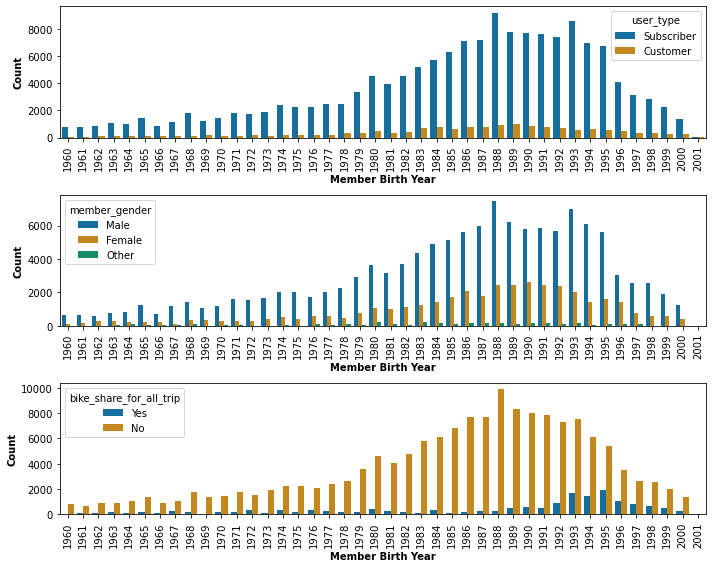

```python
fig = plt.figure(figsize = [10, 8])

# Subplot 1: member_birth_year vs user_type
plt.subplot(3, 1, 1)
sb.countplot(data = bikeDataFilteredYear, x = 'member_birth_year', hue = 'user_type', palette = 'colorblind')
plt.xticks(rotation=90)
plt.xlabel('Member Birth Year', fontsize=10, weight='bold')
plt.ylabel('Count', fontsize=10, weight='bold')

# Subplot 2: member_birth_year vs. member_gender
ax = plt.subplot(3, 1, 2)
sb.countplot(data = bikeDataFilteredYear, x = 'member_birth_year', hue = 'member_gender', palette = 'colorblind')
plt.xticks(rotation=90)
plt.xlabel('Member Birth Year', fontsize=10, weight='bold')
plt.ylabel('Count', fontsize=10, weight='bold')

# Subplot 3: clarity vs. color, use different color palette
ax = plt.subplot(3, 1, 3)
sb.countplot(data = bikeDataFilteredYear , x = 'member_birth_year', hue = 'bike_share_for_all_trip', palette = 'colorblind')
plt.xticks(rotation=90)
plt.xlabel('Member Birth Year', fontsize=10, weight='bold')
plt.ylabel('Count', fontsize=10, weight='bold')

fig.tight_layout()
plt.show()
```

> From the visualization above, we can see that most members were born between 1980 and 2000. Of this, we see that most of the rides were subsribers, males. and were not part of the bike share for all trip program.

```python
# Get the first 50 bikes with highest bike rides
top50BikeID = bikeDataFiltered['bike_id'].value_counts().sort_values(ascending=False)[:50]
```

```python
top50BikeData = bikeDataFiltered[bikeDataFiltered['bike_id'].isin(top50BikeID.index)]
```

### What is the relationship between bike id and user type, member gender, and bike share for all trip?

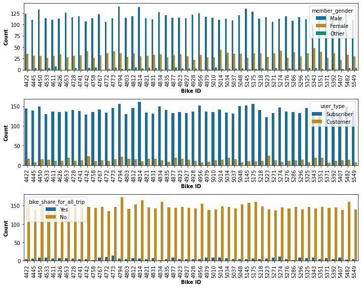

```python
fig = plt.figure(figsize = [10, 8])

# Subplot 1: bike_id vs user_type
plt.subplot(3, 1, 1)
sb.countplot(data = top50BikeData , x = 'bike_id', hue = 'member_gender', palette = 'colorblind')
plt.xticks(rotation=90)
plt.xlabel('Bike ID', fontsize=10, weight='bold')
plt.ylabel('Count', fontsize=10, weight='bold')

# Subplot 2: bike_id vs. member_gender
ax = plt.subplot(3, 1, 2)
sb.countplot(data = top50BikeData , x = 'bike_id', hue = 'user_type', palette = 'colorblind')
plt.xticks(rotation=90)
plt.xlabel('Bike ID', fontsize=10, weight='bold')
plt.ylabel('Count', fontsize=10, weight='bold')

# Subplot 3: bike_id vs. color, use different color palette
ax = plt.subplot(3, 1, 3)
sb.countplot(data = top50BikeData , x = 'bike_id', hue = 'bike_share_for_all_trip', palette = 'colorblind')
plt.xticks(rotation=90)
plt.xlabel('Bike ID', fontsize=10, weight='bold')
plt.ylabel('Count', fontsize=10, weight='bold')

fig.tight_layout()
plt.show()
```

> From the distribution above, we can also see that of the first 50 bikes with highest number of rides, most of the rides were done by Males, Subscribers, and people that were not part of the bike share for all trip program.

```python
highestAvgRideDistance = bikeDataFiltered.groupby('bike_id')['ride_distance'].mean().sort_values(ascending=False)[:30]
highestAvgRideDistance = highestAvgRideDistance.apply(np.ceil)
highestAvgRideDistance = highestAvgRideDistance.astype(int)
```

#### Which bikes have the highest average ride distance?

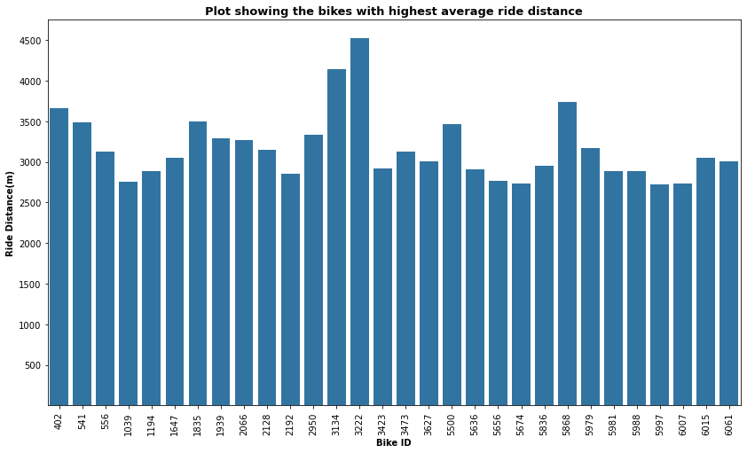

```python
fig = plt.figure(figsize = [14, 8])
sb.barplot(highestAvgRideDistance.index.values, highestAvgRideDistance, color = base_color)
plt.xticks(rotation=90);
plt.xlabel('Bike ID', fontsize=10, weight='bold')
plt.ylabel('Ride Distance(m)', fontsize=10, weight='bold')
plt.title('Plot showing the bikes with highest average ride distance', fontsize=13, weight='bold')
plt.yticks([500, 1000, 1500, 2000, 2500, 3000, 3500, 4000, 4500]);
```

> The bar plot above shows that bike 3222 and 3134 had the highest average ride distance (4523 m and 4139 m respectively).

### Did you observe any interesting relationships between the other features (not the main feature(s) of interest)?

> I also discovered that most of the members were born between 1980 and 2000. I also observed that of the top 50 bikes with highest bike rides, most of the rides were by Males, Subscribers, and people not enorolled in the bike share for all program. Furthermore, I found that of the first 50 bikes with highest number of rides, most of the riders were done by Males, Subscribers, and people that were not part of the bike share for all trip program. We observed that most of the members were born between 1980 and 2000. We also see that 1931 and 1934 have the lowest average ride duration while 1878 & 2001 has the highest average ride duration.

## Multivariate Exploration

#### What is the multivariate relationship between ride distance, member birth year, and user type?

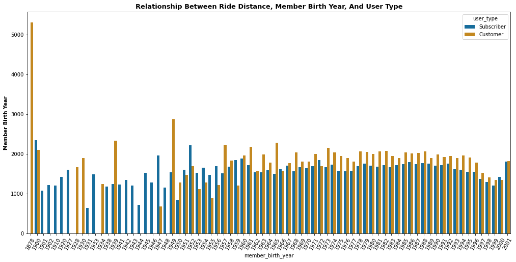

```python
# Select members born between 1960 and 2001
fig = plt.figure(figsize = [17, 8])
ax = sb.barplot(data = bikeDataFiltered, x = 'member_birth_year', y = 'ride_distance', hue = 'user_type',
           palette = 'colorblind', errwidth=0)
plt.title('Relationship between ride distance, member birth year, and user type'.title(), fontsize=13, weight='bold')
plt.ylabel('Ride Distance (m)', fontsize=10, weight='bold')
plt.ylabel('Member Birth Year', fontsize=10, weight='bold')
plt.xticks(rotation=60)
plt.show();
```

> The chart above shows the relationship between ride distance, member birth year, and user type. We see that 1878 has the highest average ride distance of all years. We also see that some years do not have data for either Subscribers or Customers e.g. 1901, 1902, 1910, etc.

#### What is the multivariate relationship between ride distance, member birth year, and member gender?

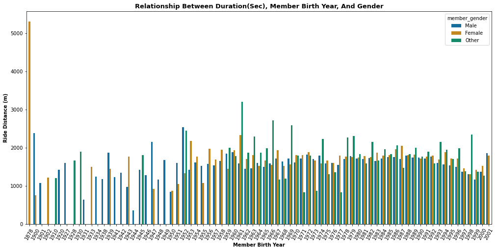

```python
# What is the relationship between ride distance, member birth year, and member gender
fig = plt.figure(figsize = [17, 8])
ax = sb.barplot(data = bikeDataFiltered, x = 'member_birth_year', y = 'ride_distance', hue = 'member_gender',
           palette = 'colorblind', errwidth=0)
plt.title('Relationship between duration(sec), member birth year, and gender'.title(), fontsize=13, weight='bold')
plt.ylabel('Ride Distance (m)', fontsize=10, weight='bold')
plt.xlabel('Member Birth Year', fontsize=10, weight='bold')
plt.xticks(rotation=60)
plt.show();
```

```python
filteredByYearSample = bikeDataFilteredYear.sample(n=500, replace = False)
```

#### What is the multivariate relationship between duration, member birth year, user type, and member birth year?

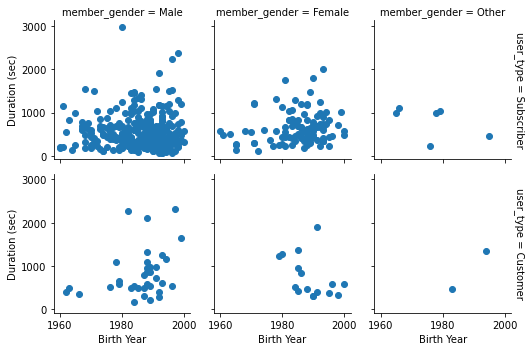

```python
g = sb.FacetGrid(data = filteredByYearSample, col = 'member_gender', row = 'user_type', size = 2.5, margin_titles = True)
g.map(plt.scatter, 'member_birth_year', 'duration_sec', color = base_color)
g.set_xlabels('Birth Year')
g.set_ylabels('Duration (sec)')

plt.show()
```

> The FacetGrid above shows the relationship between birth year, duration_sec, member_gender, and user_type. We see that there is no unique thing about the relationship. The data points for Customers are not enough.

### Were there any interesting or surprising interactions between features?

> The chart above shows the relationship between ride distance, member birth year, and user type. We see that 1878 has the highest average ride distance of all years. (and this was a female customer). We also see that some years do not have data for either Subscribers or Customers e.g. 1901, 1902, 1910, etc.

## Conclusions

> In this Project, I explored bike-sharing data set with information about individual rides made covering the greater San Francisco Bay area.

> The bike share for all trip program has no effect on ride duration.

> Most of the members were born between 1980 and 2000. Furthermore, I found that of the first 50 bikes with highest number of rides, most of the riders were done by Males, Subscribers, and people that were not part of the bike share for all trip program. We observed that most of the members were born between 1980 and 2000.